# Citrus Hill Logistic Regression

#Brief

Provided with a set of data on customer purchases of either ‘Citrus Hill’ (purchase = ‘CH’) or ‘Minute Maid’ (purchase = ‘MM’) orange juice, together with some further attributes of both the customer and the store of purchase, build the best predictive classifier of whether a customer is likely to buy Citrus Hill or Minute Maid juice.

##Data Wrangling

```r
library(tidyverse)
library(modelr)
library(janitor)
library(GGally)
library(glmulti)
library(pROC)
```

```r
oj <- clean_names(read_csv("data/orange_juice.csv"))
```

```r
glimpse(oj)
```

```
Rows: 1,070
Columns: 18
$ purchase        <chr> "CH", "CH", "CH", "MM", "CH", "CH", "CH", "CH", "CH", "CH", "CH", "CH", "CH", "CH", "CH", "CH", "MM", "MM", "MM", "CH", "CH", "CH", "…
$ weekof_purchase <dbl> 237, 239, 245, 227, 228, 230, 232, 234, 235, 238, 240, 263, 276, 268, 278, 278, 240, 268, 269, 254, 257, 258, 259, 264, 268, 269, 271…
$ store_id        <dbl> 1, 1, 1, 1, 7, 7, 7, 7, 7, 7, 7, 7, 7, 7, 7, 7, 1, 2, 2, 7, 7, 1, 7, 7, 7, 7, 7, 7, 7, 7, 2, 7, 2, 2, 3, 3, 1, 1, 4, 4, 4, 4, 4, 4, 4…
$ price_ch        <dbl> 1.75, 1.75, 1.86, 1.69, 1.69, 1.69, 1.69, 1.75, 1.75, 1.75, 1.86, 1.86, 1.99, 1.86, 2.06, 2.06, 1.75, 1.86, 1.86, 1.86, 1.86, 1.76, 1…
$ price_mm        <dbl> 1.99, 1.99, 2.09, 1.69, 1.69, 1.99, 1.99, 1.99, 1.99, 1.99, 2.09, 2.13, 2.13, 2.13, 2.13, 2.13, 1.99, 2.18, 2.18, 2.18, 2.18, 2.18, 2…
$ disc_ch         <dbl> 0.00, 0.00, 0.17, 0.00, 0.00, 0.00, 0.00, 0.00, 0.00, 0.00, 0.00, 0.27, 0.00, 0.00, 0.00, 0.00, 0.00, 0.00, 0.00, 0.00, 0.00, 0.00, 0…
$ disc_mm         <dbl> 0.00, 0.30, 0.00, 0.00, 0.00, 0.00, 0.40, 0.40, 0.40, 0.40, 0.00, 0.00, 0.54, 0.00, 0.00, 0.00, 0.30, 0.00, 0.00, 0.00, 0.00, 0.00, 0…
$ special_ch      <dbl> 0, 0, 0, 0, 0, 0, 1, 1, 0, 0, 0, 0, 0, 0, 0, 0, 0, 0, 0, 0, 0, 0, 0, 1, 0, 1, 0, 0, 1, 0, 0, 1, 0, 1, 0, 0, 0, 0, 1, 0, 0, 0, 0, 0, 0…
$ special_mm      <dbl> 0, 1, 0, 0, 0, 1, 1, 0, 0, 0, 0, 0, 1, 0, 0, 0, 1, 1, 0, 0, 0, 0, 0, 0, 0, 0, 0, 0, 0, 0, 0, 0, 1, 0, 0, 0, 0, 0, 0, 1, 0, 0, 0, 0, 0…
$ loyal_ch        <dbl> 0.500000, 0.600000, 0.680000, 0.400000, 0.956535, 0.965228, 0.972182, 0.977746, 0.982197, 0.985757, 0.988606, 0.990885, 0.992708, 0.6…
$ sale_price_mm   <dbl> 1.99, 1.69, 2.09, 1.69, 1.69, 1.99, 1.59, 1.59, 1.59, 1.59, 2.09, 2.13, 1.59, 2.13, 2.13, 2.13, 1.69, 2.18, 2.18, 2.18, 2.18, 2.18, 2…
$ sale_price_ch   <dbl> 1.75, 1.75, 1.69, 1.69, 1.69, 1.69, 1.69, 1.75, 1.75, 1.75, 1.86, 1.59, 1.99, 1.86, 2.06, 2.06, 1.75, 1.86, 1.86, 1.86, 1.86, 1.76, 1…
$ price_diff      <dbl> 0.24, -0.06, 0.40, 0.00, 0.00, 0.30, -0.10, -0.16, -0.16, -0.16, 0.23, 0.54, -0.40, 0.27, 0.07, 0.07, -0.06, 0.32, 0.32, 0.32, 0.32, …
$ store7          <chr> "No", "No", "No", "No", "Yes", "Yes", "Yes", "Yes", "Yes", "Yes", "Yes", "Yes", "Yes", "Yes", "Yes", "Yes", "No", "No", "No", "Yes", …
$ pct_disc_mm     <dbl> 0.000000, 0.150754, 0.000000, 0.000000, 0.000000, 0.000000, 0.201005, 0.201005, 0.201005, 0.201005, 0.000000, 0.000000, 0.253521, 0.0…
$ pct_disc_ch     <dbl> 0.000000, 0.000000, 0.091398, 0.000000, 0.000000, 0.000000, 0.000000, 0.000000, 0.000000, 0.000000, 0.000000, 0.145161, 0.000000, 0.0…
$ list_price_diff <dbl> 0.24, 0.24, 0.23, 0.00, 0.00, 0.30, 0.30, 0.24, 0.24, 0.24, 0.23, 0.27, 0.14, 0.27, 0.07, 0.07, 0.24, 0.32, 0.32, 0.32, 0.32, 0.42, 0…
$ store           <dbl> 1, 1, 1, 1, 0, 0, 0, 0, 0, 0, 0, 0, 0, 0, 0, 0, 1, 2, 2, 0, 0, 1, 0, 0, 0, 0, 0, 0, 0, 0, 2, 0, 2, 2, 3, 3, 1, 1, 4, 4, 4, 4, 4, 4, 4…
```

```r
oj <- oj %>%
  rename(
    week_of_purchase = weekof_purchase,
    store_7 = store7
  ) %>%
  mutate(
    special_ch = as.logical(special_ch),
    special_mm = as.logical(special_mm),
    store_7 = store_7 == "Yes",
    store_id = as_factor(store_id),
    store = as_factor(store)
  )
glimpse(oj)
```

```
Rows: 1,070
Columns: 18
$ purchase         <chr> "CH", "CH", "CH", "MM", "CH", "CH", "CH", "CH", "CH", "CH", "CH", "CH", "CH", "CH", "CH", "CH", "MM", "MM", "MM", "CH", "CH", "CH", …
$ week_of_purchase <dbl> 237, 239, 245, 227, 228, 230, 232, 234, 235, 238, 240, 263, 276, 268, 278, 278, 240, 268, 269, 254, 257, 258, 259, 264, 268, 269, 27…
$ store_id         <fct> 1, 1, 1, 1, 7, 7, 7, 7, 7, 7, 7, 7, 7, 7, 7, 7, 1, 2, 2, 7, 7, 1, 7, 7, 7, 7, 7, 7, 7, 7, 2, 7, 2, 2, 3, 3, 1, 1, 4, 4, 4, 4, 4, 4, …
$ price_ch         <dbl> 1.75, 1.75, 1.86, 1.69, 1.69, 1.69, 1.69, 1.75, 1.75, 1.75, 1.86, 1.86, 1.99, 1.86, 2.06, 2.06, 1.75, 1.86, 1.86, 1.86, 1.86, 1.76, …
$ price_mm         <dbl> 1.99, 1.99, 2.09, 1.69, 1.69, 1.99, 1.99, 1.99, 1.99, 1.99, 2.09, 2.13, 2.13, 2.13, 2.13, 2.13, 1.99, 2.18, 2.18, 2.18, 2.18, 2.18, …
$ disc_ch          <dbl> 0.00, 0.00, 0.17, 0.00, 0.00, 0.00, 0.00, 0.00, 0.00, 0.00, 0.00, 0.27, 0.00, 0.00, 0.00, 0.00, 0.00, 0.00, 0.00, 0.00, 0.00, 0.00, …
$ disc_mm          <dbl> 0.00, 0.30, 0.00, 0.00, 0.00, 0.00, 0.40, 0.40, 0.40, 0.40, 0.00, 0.00, 0.54, 0.00, 0.00, 0.00, 0.30, 0.00, 0.00, 0.00, 0.00, 0.00, …
$ special_ch       <lgl> FALSE, FALSE, FALSE, FALSE, FALSE, FALSE, TRUE, TRUE, FALSE, FALSE, FALSE, FALSE, FALSE, FALSE, FALSE, FALSE, FALSE, FALSE, FALSE, F…
$ special_mm       <lgl> FALSE, TRUE, FALSE, FALSE, FALSE, TRUE, TRUE, FALSE, FALSE, FALSE, FALSE, FALSE, TRUE, FALSE, FALSE, FALSE, TRUE, TRUE, FALSE, FALSE…
$ loyal_ch         <dbl> 0.500000, 0.600000, 0.680000, 0.400000, 0.956535, 0.965228, 0.972182, 0.977746, 0.982197, 0.985757, 0.988606, 0.990885, 0.992708, 0.…
$ sale_price_mm    <dbl> 1.99, 1.69, 2.09, 1.69, 1.69, 1.99, 1.59, 1.59, 1.59, 1.59, 2.09, 2.13, 1.59, 2.13, 2.13, 2.13, 1.69, 2.18, 2.18, 2.18, 2.18, 2.18, …
$ sale_price_ch    <dbl> 1.75, 1.75, 1.69, 1.69, 1.69, 1.69, 1.69, 1.75, 1.75, 1.75, 1.86, 1.59, 1.99, 1.86, 2.06, 2.06, 1.75, 1.86, 1.86, 1.86, 1.86, 1.76, …
$ price_diff       <dbl> 0.24, -0.06, 0.40, 0.00, 0.00, 0.30, -0.10, -0.16, -0.16, -0.16, 0.23, 0.54, -0.40, 0.27, 0.07, 0.07, -0.06, 0.32, 0.32, 0.32, 0.32,…
$ store_7          <lgl> FALSE, FALSE, FALSE, FALSE, TRUE, TRUE, TRUE, TRUE, TRUE, TRUE, TRUE, TRUE, TRUE, TRUE, TRUE, TRUE, FALSE, FALSE, FALSE, TRUE, TRUE,…
$ pct_disc_mm      <dbl> 0.000000, 0.150754, 0.000000, 0.000000, 0.000000, 0.000000, 0.201005, 0.201005, 0.201005, 0.201005, 0.000000, 0.000000, 0.253521, 0.…
$ pct_disc_ch      <dbl> 0.000000, 0.000000, 0.091398, 0.000000, 0.000000, 0.000000, 0.000000, 0.000000, 0.000000, 0.000000, 0.000000, 0.145161, 0.000000, 0.…
$ list_price_diff  <dbl> 0.24, 0.24, 0.23, 0.00, 0.00, 0.30, 0.30, 0.24, 0.24, 0.24, 0.23, 0.27, 0.14, 0.27, 0.07, 0.07, 0.24, 0.32, 0.32, 0.32, 0.32, 0.42, …
$ store            <fct> 1, 1, 1, 1, 0, 0, 0, 0, 0, 0, 0, 0, 0, 0, 0, 0, 1, 2, 2, 0, 0, 1, 0, 0, 0, 0, 0, 0, 0, 0, 2, 0, 2, 2, 3, 3, 1, 1, 4, 4, 4, 4, 4, 4, …
```

```r
oj %>%
  group_by(purchase) %>%
  summarise(n = n())
```

| purchase | n |
| --- | --- |
| CH | 653 |
| MM | 417 |

```r
oj %>%
  group_by(week_of_purchase) %>%
  summarise(n = n())
```

| week_of_purchase | n |
| --- | --- |
| 227 | 15 |
| 228 | 22 |
| 229 | 23 |
| 230 | 19 |
| 231 | 20 |
| 232 | 19 |
| 233 | 28 |
| 234 | 18 |
| 235 | 16 |
| 236 | 23 |

[output cut: 42 more lines]

Adding in a week_of_purchase_fac variable so we can test the effect of each treatment of week.

```r
oj <- oj %>%
  mutate(week_of_purchase_fac = as_factor(week_of_purchase))
```

Mutating the dependent variable to be logical, using purchase_mm as level “MM” is the minority

```r
oj <- oj %>%
  mutate(purchase_mm = purchase == "MM") %>%
  select(-purchase)
```

Checking for aliases in the independent variables

```r
alias(purchase_mm ~ ., data = oj)
```

```
Model :
purchase_mm ~ week_of_purchase + store_id + price_ch + price_mm +
    disc_ch + disc_mm + special_ch + special_mm + loyal_ch +
    sale_price_mm + sale_price_ch + price_diff + store_7 + pct_disc_mm +
    pct_disc_ch + list_price_diff + store + week_of_purchase_fac

Complete :
                        (Intercept) week_of_purchase store_id2 store_id3 store_id4 store_id7 price_ch price_mm disc_ch disc_mm special_chTRUE special_mmTRUE
sale_price_mm                 0           0                0         0         0         0         0        1        0      -1       0              0
sale_price_ch                 0           0                0         0         0         0         1        0       -1       0       0              0
price_diff                    0           0                0         0         0         0        -1        1        1      -1       0              0
store_7TRUE                   0           0                0         0         0         1         0        0        0       0       0              0
list_price_diff               0           0                0         0         0         0        -1        1        0       0       0              0
store1                        1           0               -1        -1        -1        -1         0        0        0       0       0              0
store2                        0           0                1         0         0         0         0        0        0       0       0              0
store3                        0           0                0         1         0         0         0        0        0       0       0              0
store4                        0           0                0         0         1         0         0        0        0       0       0              0
week_of_purchase_fac278 -227/51        1/51                0         0         0         0         0        0        0       0       0              0
                        loyal_ch pct_disc_mm pct_disc_ch week_of_purchase_fac228 week_of_purchase_fac229 week_of_purchase_fac230 week_of_purchase_fac231
sale_price_mm                 0        0           0           0                       0                       0                       0
sale_price_ch                 0        0           0           0                       0                       0                       0
price_diff                    0        0           0           0                       0                       0                       0
store_7TRUE                   0        0           0           0                       0                       0                       0
list_price_diff               0        0           0           0                       0                       0                       0
store1                        0        0           0           0                       0                       0                       0
store2                        0        0           0           0                       0                       0                       0
store3                        0        0           0           0                       0                       0                       0
store4                        0        0           0           0                       0                       0                       0
week_of_purchase_fac278       0        0           0       -1/51                   -2/51                   -1/17                   -4/51
                        week_of_purchase_fac232 week_of_purchase_fac233 week_of_purchase_fac234 week_of_purchase_fac235 week_of_purchase_fac236
sale_price_mm                 0                       0                       0                       0                       0
sale_price_ch                 0                       0                       0                       0                       0
price_diff                    0                       0                       0                       0                       0
store_7TRUE                   0                       0                       0                       0                       0
list_price_diff               0                       0                       0                       0                       0
store1                        0                       0                       0                       0                       0
store2                        0                       0                       0                       0                       0
store3                        0                       0                       0                       0                       0
store4                        0                       0                       0                       0                       0
week_of_purchase_fac278   -5/51                   -2/17                   -7/51                   -8/51                   -3/17
```

[output cut: 84 more lines]

```
store2                        0                       0                       0                       0                       0
store3                        0                       0                       0                       0                       0
store4                        0                       0                       0                       0                       0
week_of_purchase_fac278  -15/17                  -46/51                  -47/51                  -16/17                  -49/51
                        week_of_purchase_fac277
sale_price_mm                 0
sale_price_ch                 0
price_diff                    0
store_7TRUE                   0
list_price_diff               0
store1                        0
store2                        0
store3                        0
store4                        0
week_of_purchase_fac278  -50/51
```

sale_price_mm, sale_price_ch, price_diff, store_7, list_price_diff and store can be derived from other variables, so removing them. There is also an alias between week_of_purchase and week_of_purchase_fac, so, again, only including one of these variable in the model.

```r
oj_trim <- oj %>%
  select(-c("sale_price_mm", "sale_price_ch", "price_diff", "store_7", "list_price_diff", "store"))
```

##Model

Splitting the variables and look at pairs plots to investigate the relationships of variables with purchase_mm

```r
names(oj_trim)
```

```
 [1] "week_of_purchase"     "store_id"             "price_ch"             "price_mm"             "disc_ch"              "disc_mm"
 [7] "special_ch"           "special_mm"           "loyal_ch"             "pct_disc_mm"          "pct_disc_ch"          "week_of_purchase_fac"
[13] "purchase_mm"
```

```r
set1 <- oj_trim %>%
  select(week_of_purchase, store_id, price_ch, price_mm, disc_ch, disc_mm, purchase_mm)

set2 <- oj_trim %>%
  select(special_ch, special_mm, loyal_ch, pct_disc_mm, pct_disc_ch, purchase_mm)
```

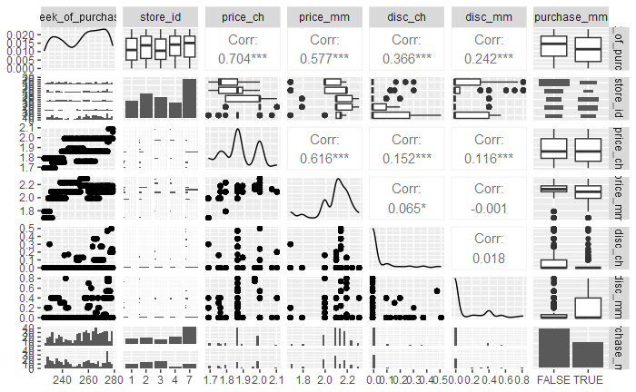

```r
ggpairs(set1)
```

```r
ggsave("pairs_plot_set1.png", width = 10, height = 10, units = "in")
```

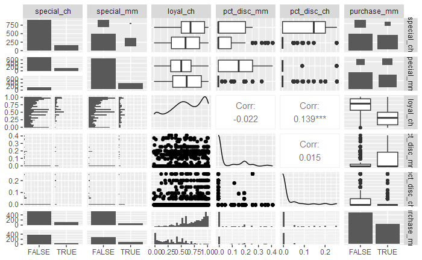

```r
ggpairs(set2)
```

```r
ggsave("pairs_plot_set2.png", width = 10, height = 10, units = "in")
```

Looking at how purchase_mm varies with week_of_purchase_fac

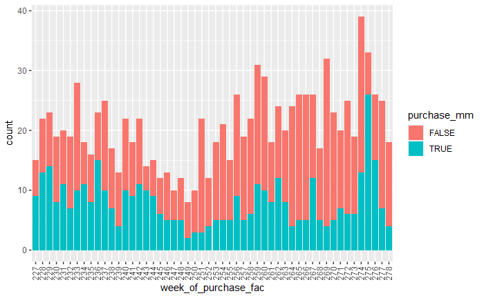

```r
oj_trim %>%
  ggplot(aes(x = week_of_purchase_fac, fill = purchase_mm)) +
  geom_bar() +
  theme(axis.text.x = element_text(angle = 90, hjust = 1, vjust = 0.5))
```

```r
set.seed(42)

test_indices <- sample(1:nrow(oj_trim), size = as.integer(nrow(oj_trim) * 0.2))

train <- oj_trim %>%
  slice(-test_indices)

test <- oj_trim %>%
  slice(test_indices)
#check
nrow(train) + nrow(test) == nrow(oj_trim)
```

```
[1] TRUE
```

Checking the distribution of outcome in the training and testing sets to see that they are roughly comparable.

```r
train %>%
  tabyl(purchase_mm)
```

```
 purchase_mm   n   percent
       FALSE 531 0.6203271
        TRUE 325 0.3796729
```

```r
test %>%
  tabyl(purchase_mm)
```

```
 purchase_mm   n   percent
       FALSE 122 0.5700935
        TRUE  92 0.4299065
```

Simple models with all main effects, using BIC here to choose which of these variables to carry forward to automated model searches.

```r
mod1 <- glm(purchase_mm ~ . - week_of_purchase_fac, data = train, family = binomial(link = "logit"))
summary(mod1)
```

```
Call:
glm(formula = purchase_mm ~ . - week_of_purchase_fac, family = binomial(link = "logit"),
    data = train)

Coefficients:
                   Estimate Std. Error z value Pr(>|z|)
(Intercept)        4.277282   2.372103   1.803 0.071363 .
week_of_purchase  -0.003909   0.012890  -0.303 0.761681
store_id2         -0.199540   0.332971  -0.599 0.548992
store_id3         -0.233254   0.448067  -0.521 0.602660
store_id4         -0.496144   0.485745  -1.021 0.307061
store_id7         -0.628206   0.327246  -1.920 0.054899 .
price_ch           3.631856   2.134220   1.702 0.088807 .
price_mm          -3.440573   1.030416  -3.339 0.000841 ***
disc_ch           25.830234  21.534693   1.199 0.230345
disc_mm           22.524957  10.505659   2.144 0.032027 *
special_chTRUE     0.385411   0.384415   1.003 0.316059
special_mmTRUE     0.514612   0.312862   1.645 0.100001
loyal_ch          -6.429735   0.471319 -13.642  < 2e-16 ***
pct_disc_mm      -42.850313  21.995005  -1.948 0.051393 .
pct_disc_ch      -56.142131  40.691385  -1.380 0.167677
---
Signif. codes:  0 ‘***’ 0.001 ‘**’ 0.01 ‘*’ 0.05 ‘.’ 0.1 ‘ ’ 1

(Dispersion parameter for binomial family taken to be 1)

    Null deviance: 1136.60  on 855  degrees of freedom
Residual deviance:  639.68  on 841  degrees of freedom
AIC: 669.68

Number of Fisher Scoring iterations: 5
```

```r
bic(mod1)
```

```
[1] 740.9665
```

```r
mod2 <- glm(purchase_mm ~ . - week_of_purchase, data = train, family = binomial(link = "logit"))
summary(mod2)
```

```
Call:
glm(formula = purchase_mm ~ . - week_of_purchase, family = binomial(link = "logit"),
    data = train)

Coefficients:
                          Estimate Std. Error z value Pr(>|z|)
(Intercept)              6.604e+00  6.977e+00   0.947   0.3439
store_id2               -5.995e-02  3.781e-01  -0.159   0.8740
store_id3               -1.586e-01  6.302e-01  -0.252   0.8012
store_id4               -2.147e-01  6.640e-01  -0.323   0.7464
store_id7               -6.565e-01  3.899e-01  -1.684   0.0922 .
price_ch                 1.635e+00  3.585e+00   0.456   0.6484
price_mm                -3.341e+00  1.985e+00  -1.683   0.0923 .
disc_ch                  6.146e+01  3.342e+01   1.839   0.0659 .
disc_mm                  1.292e+01  1.426e+01   0.906   0.3648
special_chTRUE           8.653e-01  5.707e-01   1.516   0.1295
special_mmTRUE           3.569e-01  4.282e-01   0.833   0.4046
loyal_ch                -7.170e+00  5.382e-01 -13.322   <2e-16 ***
pct_disc_mm             -2.533e+01  2.955e+01  -0.857   0.3914
pct_disc_ch             -1.242e+02  6.296e+01  -1.973   0.0484 *
week_of_purchase_fac228 -2.322e-02  9.900e-01  -0.023   0.9813
week_of_purchase_fac229  8.318e-01  1.080e+00   0.770   0.4412
week_of_purchase_fac230 -1.688e-04  1.095e+00   0.000   0.9999
week_of_purchase_fac231  1.445e+00  1.214e+00   1.190   0.2341
week_of_purchase_fac232 -1.965e-01  1.151e+00  -0.171   0.8644
week_of_purchase_fac233 -8.144e-01  1.186e+00  -0.687   0.4922
week_of_purchase_fac234  6.455e-01  1.307e+00   0.494   0.6214
week_of_purchase_fac235  6.568e-01  1.244e+00   0.528   0.5976
week_of_purchase_fac236  1.586e+00  1.209e+00   1.312   0.1896
week_of_purchase_fac237  2.313e-01  1.200e+00   0.193   0.8472
week_of_purchase_fac238 -4.012e-01  1.319e+00  -0.304   0.7611
week_of_purchase_fac239 -3.568e-02  1.435e+00  -0.025   0.9802
week_of_purchase_fac240  1.915e+00  1.350e+00   1.419   0.1560
week_of_purchase_fac241  1.052e+00  1.353e+00   0.777   0.4369
week_of_purchase_fac242  1.790e-01  1.427e+00   0.125   0.9002
week_of_purchase_fac243  1.475e+00  1.558e+00   0.947   0.3438
week_of_purchase_fac244  2.033e+00  1.628e+00   1.248   0.2119
week_of_purchase_fac245 -4.925e-01  1.783e+00  -0.276   0.7824
week_of_purchase_fac246  7.319e-01  1.512e+00   0.484   0.6284
week_of_purchase_fac247  7.898e-01  1.669e+00   0.473   0.6361
```

[output cut: 26 more lines]

```
week_of_purchase_fac274  1.268e+00  1.642e+00   0.772   0.4399
week_of_purchase_fac275  2.581e+00  1.655e+00   1.560   0.1188
week_of_purchase_fac276  1.450e+00  1.673e+00   0.867   0.3861
week_of_purchase_fac277  4.817e-01  1.961e+00   0.246   0.8059
week_of_purchase_fac278 -6.764e-01  1.942e+00  -0.348   0.7277
---
Signif. codes:  0 ‘***’ 0.001 ‘**’ 0.01 ‘*’ 0.05 ‘.’ 0.1 ‘ ’ 1

(Dispersion parameter for binomial family taken to be 1)

    Null deviance: 1136.60  on 855  degrees of freedom
Residual deviance:  586.74  on 791  degrees of freedom
AIC: 716.74

Number of Fisher Scoring iterations: 14
```

```r
bic(mod2)
```

```
[1] 1025.638
```

Automated fit guided by BIC values

```r
glmulti_search_all_mains <- glmulti(
  purchase_mm ~ . - week_of_purchase_fac,
  data = train,
  level = 1,               # No interaction considered
  method = "h",            # Exhaustive approach
  crit = "bic",            # BIC as criteria
  confsetsize = 10,        # Keep 10 best models
  plotty = F,
  report = T,              # No plots, but provide interim reports
  fitfunction = "glm",     # glm function
  family = binomial(link = "logit")) # binomial family for logistic regression
```

```
Initialization...
TASK: Exhaustive screening of candidate set.
Fitting...

After 50 models:
Best model: purchase_mm~1+week_of_purchase+price_ch+price_mm+disc_ch+disc_mm
Crit= 1090.10687793055
Mean crit= 1097.31562205472

After 100 models:
Best model: purchase_mm~1+price_ch+price_mm+disc_ch+special_mm
Crit= 1081.84830763198
Mean crit= 1086.89023658598

After 150 models:
Best model: purchase_mm~1+disc_mm+loyal_ch
Crit= 705.890997106201
Mean crit= 726.202876052268

After 200 models:
Best model: purchase_mm~1+price_ch+price_mm+disc_ch+disc_mm+loyal_ch
Crit= 695.031304999578
Mean crit= 700.500591336211

After 250 models:
Best model: purchase_mm~1+price_ch+price_mm+disc_ch+disc_mm+loyal_ch
Crit= 695.031304999578
Mean crit= 699.392979546561

After 300 models:
Best model: purchase_mm~1+price_ch+price_mm+disc_ch+disc_mm+loyal_ch
Crit= 695.031304999578
Mean crit= 699.392979546561

After 350 models:
Best model: purchase_mm~1+price_ch+price_mm+disc_ch+disc_mm+loyal_ch
Crit= 695.031304999578
Mean crit= 699.392979546561

After 400 models:
```

[output cut: 159 more lines]

```
After 2000 models:
Best model: purchase_mm~1+price_ch+price_mm+disc_mm+loyal_ch+pct_disc_ch
Crit= 694.568910360485
Mean crit= 696.122531977824

After 2050 models:
Best model: purchase_mm~1+price_ch+price_mm+disc_mm+loyal_ch+pct_disc_ch
Crit= 694.568910360485
Mean crit= 696.122531977824

After 2100 models:
Best model: purchase_mm~1+price_ch+price_mm+disc_mm+loyal_ch+pct_disc_ch
Crit= 694.568910360485
Mean crit= 696.122531977824
Completed.
```

```r
summary(glmulti_search_all_mains)
```

```
$name
[1] "glmulti.analysis"

$method
[1] "h"

$fitting
[1] "glm"

$crit
[1] "bic"

$level
[1] 1

$marginality
[1] FALSE

$confsetsize
[1] 10

$bestic
[1] 694.5689

$icvalues
 [1] 694.5689 695.0313 695.6738 695.7676 696.2251 696.3335 696.6036 696.7221 697.0783 697.2211

$bestmodel
[1] "purchase_mm ~ 1 + price_ch + price_mm + disc_mm + loyal_ch + " "    pct_disc_ch"

$modelweights
 [1] 0.19912440 0.15802171 0.11460340 0.10935462 0.08699320 0.08240370 0.07199264 0.06785091 0.05678430 0.05287112

$includeobjects
[1] TRUE
```

Using the main effects model with lowest BIC from above and perform another exhaustive search looking to add a single pair

```r
glmulti_search_all_mains_one_pair <- glmulti(
  purchase_mm ~ price_ch + price_mm + disc_mm + loyal_ch + pct_disc_ch,
  data = train,
  level = 2,               # Interactions considered
  method = "h",            # Exhaustive approach
  crit = "bic",            # BIC as criteria
  confsetsize = 10,        # Keep 10 best models
  marginality = TRUE,      # consider pairs only if both main effects in model
  minsize = 6,             # minsize, maxsize and marginality here force
  maxsize = 6,             # inclusion of a single pair beyond the five main effects
  plotty = F,
  report = T,              # No plots, but provide interim reports
  fitfunction = "glm",     # glm function
  family = binomial(link = "logit")) # binomial family for logistic regression
```

```
Initialization...
TASK: Exhaustive screening of candidate set.
Fitting...

After 50 models:
Best model: purchase_mm~1+price_ch+price_mm+disc_mm+loyal_ch+price_mm:price_ch+disc_mm:price_ch
Crit= 712.096425795164
Mean crit= 714.452501476539

After 100 models:
Best model: purchase_mm~1+price_ch+price_mm+disc_mm+loyal_ch+pct_disc_ch+disc_mm:price_mm
Crit= 696.457403517834
Mean crit= 699.305994500254
Completed.
```

```r
summary(glmulti_search_all_mains_one_pair)
```

```
$name
[1] "glmulti.analysis"

$method
[1] "h"

$fitting
[1] "glm"

$crit
[1] "bic"

$level
[1] 2

$marginality
[1] TRUE

$confsetsize
[1] 10

$bestic
[1] 696.4574

$icvalues
 [1] 696.4574 697.0663 697.2972 699.9742 700.1569 700.2092 700.2201 700.2700 700.2893 701.1193

$bestmodel
[1] "purchase_mm ~ 1 + price_ch + price_mm + disc_mm + loyal_ch + " "    pct_disc_ch + disc_mm:price_mm"

$modelweights
 [1] 0.29215148 0.21547184 0.19197751 0.05034339 0.04594949 0.04476318 0.04451927 0.04342169 0.04300450 0.02839765

$includeobjects
[1] TRUE
```

Getting out models with two pairs and three pairs

```r
glmulti_search_all_mains_two_pairs <- glmulti(
  purchase_mm ~ price_ch + price_mm + disc_mm + loyal_ch + pct_disc_ch,
  data = train,
  level = 2,               # Interactions considered
  method = "h",            # Exhaustive approach
  crit = "bic",            # BIC as criteria
  confsetsize = 10,        # Keep 10 best models
  marginality = TRUE,      # consider pairs only if both main effects in model
  minsize = 7,             # minsize, maxsize and marginality here force
  maxsize = 7,             # inclusion of a single pair beyond the five main effects
  plotty = F,
  report = T,              # No plots, but provide interim reports
  fitfunction = "glm",     # glm function
  family = binomial(link = "logit")) # binomial family for logistic regression
```

```
Initialization...
TASK: Exhaustive screening of candidate set.
Fitting...

After 50 models:
Best model: purchase_mm~1+price_ch+price_mm+disc_mm+loyal_ch+price_mm:price_ch+disc_mm:price_ch+loyal_ch:price_mm
Crit= 716.57122955301
Mean crit= 718.669218081899

After 100 models:
Best model: purchase_mm~1+price_mm+disc_mm+loyal_ch+pct_disc_ch+disc_mm:price_mm+loyal_ch:price_mm+pct_disc_ch:loyal_ch
Crit= 704.577835788486
Mean crit= 706.773406222112

After 150 models:
Best model: purchase_mm~1+price_ch+price_mm+disc_mm+loyal_ch+pct_disc_ch+pct_disc_ch:price_ch+pct_disc_ch:loyal_ch
Crit= 702.230065261241
Mean crit= 703.866700879998
Completed.
```

```r
summary(glmulti_search_all_mains_two_pairs)
```

```
$name
[1] "glmulti.analysis"

$method
[1] "h"

$fitting
[1] "glm"

$crit
[1] "bic"

$level
[1] 2

$marginality
[1] TRUE

$confsetsize
[1] 10

$bestic
[1] 702.2301

$icvalues
 [1] 702.2301 702.7814 702.9728 703.1790 703.2187 703.6705 704.5778 705.0800 705.1957 705.7610

$bestmodel
[1] "purchase_mm ~ 1 + price_ch + price_mm + disc_mm + loyal_ch + " "    pct_disc_ch + pct_disc_ch:price_ch + pct_disc_ch:loyal_ch"

$modelweights
 [1] 0.19548536 0.14838249 0.13484487 0.12163197 0.11924597 0.09513004 0.06043692 0.04701775 0.04437540 0.03344925

$includeobjects
[1] TRUE
```

```r
glmulti_search_all_mains_three_pairs <- glmulti(
  purchase_mm ~ price_ch + price_mm + disc_mm + loyal_ch + pct_disc_ch,
  data = train,
  level = 2,               # Interactions considered
  method = "h",            # Exhaustive approach
  crit = "bic",            # BIC as criteria
  confsetsize = 10,        # Keep 10 best models
  marginality = TRUE,      # consider pairs only if both main effects in model
  minsize = 8,             # minsize, maxsize and marginality here force
  maxsize = 8,             # inclusion of a single pair beyond the five main effects
  plotty = F,
  report = T,              # No plots, but provide interim reports
  fitfunction = "glm",     # glm function
  family = binomial(link = "logit")) # binomial family for logistic regression
```

```
Initialization...
TASK: Exhaustive screening of candidate set.
Fitting...

After 50 models:
Best model: purchase_mm~1+price_ch+disc_mm+loyal_ch+pct_disc_ch+disc_mm:price_ch+pct_disc_ch:price_ch+pct_disc_ch:disc_mm+pct_disc_ch:loyal_ch
Crit= 712.201075572691
Mean crit= 720.500100754075

After 100 models:
Best model: purchase_mm~1+price_ch+price_mm+disc_mm+loyal_ch+pct_disc_ch+price_mm:price_ch+pct_disc_ch:price_ch+pct_disc_ch:loyal_ch
Crit= 707.448304260201
Mean crit= 708.67451237866

After 150 models:
Best model: purchase_mm~1+price_ch+price_mm+disc_mm+loyal_ch+pct_disc_ch+disc_mm:price_mm+pct_disc_ch:price_ch+pct_disc_ch:loyal_ch
Crit= 704.17207367971
Mean crit= 705.069938077106

After 200 models:
Best model: purchase_mm~1+price_ch+price_mm+disc_mm+loyal_ch+pct_disc_ch+disc_mm:price_mm+loyal_ch:price_mm+pct_disc_ch:loyal_ch
Crit= 703.73131734468
Mean crit= 704.768352380209
Completed.
```

```r
summary(glmulti_search_all_mains_three_pairs)
```

```
$name
[1] "glmulti.analysis"

$method
[1] "h"

$fitting
[1] "glm"

$crit
[1] "bic"

$level
[1] 2

$marginality
[1] TRUE

$confsetsize
[1] 10

$bestic
[1] 703.7313

$icvalues
 [1] 703.7313 704.1721 704.2192 704.3256 704.9835 705.0501 705.0706 705.3361 705.3666 705.4285

$bestmodel
[1] "purchase_mm ~ 1 + price_ch + price_mm + disc_mm + loyal_ch + "
[2] "    pct_disc_ch + disc_mm:price_mm + loyal_ch:price_mm + pct_disc_ch:loyal_ch"

$modelweights
 [1] 0.16102571 0.12917730 0.12617121 0.11963130 0.08609886 0.08327558 0.08242863 0.07217976 0.07108956 0.06892210

$includeobjects
[1] TRUE
```

The set of all possible models with all main effects and all possible pairs is too large to search exhaustively, so using a genetic algorithm search instead

```r
glmulti_ga_search_with_pairs <- glmulti(
  purchase_mm ~ . - week_of_purchase_fac,
  data = train,
  level = 2,               # Interactions considered
  method = "g",            # Genetic algorithm approach
  crit = "bic",            # BIC as criteria
  confsetsize = 10,        # Keep 10 best models
  marginality = TRUE,      # consider pairs only if both main effects in model
  plotty = F,
  report = T,              # No plots, but provide interim reports
  fitfunction = "glm",     # glm function
  family = binomial(link = "logit")) # binomial family for logistic regression
```

```
Initialization...
TASK: Genetic algorithm in the candidate set.
Initialization...
Algorithm started...
```

```
After 10 generations:
Best model: purchase_mm~1+store_id+week_of_purchase+price_ch+price_mm+disc_ch+disc_mm+special_ch+special_mm+loyal_ch+pct_disc_mm+pct_disc_ch+price_mm:price_ch+disc_ch:price_ch+disc_mm:price_mm+special_ch:week_of_purchase+special_mm:disc_mm+loyal_ch:special_mm+pct_disc_mm:price_ch+pct_disc_mm:price_m…
Crit= 852.749804674438
Mean crit= 881.927208366975
Change in best IC: -9147.25019532556 / Change in mean IC: -9118.07279163303
```

```
After 20 generations:
Best model: purchase_mm~1+store_id+week_of_purchase+price_ch+price_mm+disc_ch+disc_mm+special_ch+special_mm+loyal_ch+pct_disc_mm+pct_disc_ch+disc_mm:price_mm+special_ch:week_of_purchase+loyal_ch:special_mm+pct_disc_mm:price_ch+pct_disc_mm:price_mm+pct_disc_mm:disc_ch+pct_disc_mm:special_ch+pct_disc_…
Crit= 828.225283262824
Mean crit= 864.02945341606
Change in best IC: -24.5245214116139 / Change in mean IC: -17.8977549509151
```

```
After 30 generations:
Best model: purchase_mm~1+store_id+week_of_purchase+price_ch+price_mm+disc_ch+disc_mm+special_ch+special_mm+loyal_ch+pct_disc_mm+pct_disc_ch+disc_mm:price_mm+special_ch:week_of_purchase+special_ch:disc_mm+loyal_ch:special_mm+pct_disc_mm:price_mm+pct_disc_mm:disc_ch+pct_disc_mm:special_ch+pct_disc_ch…
Crit= 789.227654348454
Mean crit= 823.056379917336
Change in best IC: -38.9976289143705 / Change in mean IC: -40.9730734987239
```

```
After 40 generations:
Best model: purchase_mm~1+week_of_purchase+price_ch+price_mm+disc_ch+disc_mm+special_ch+special_mm+loyal_ch+pct_disc_mm+pct_disc_ch+disc_mm:price_mm+special_ch:week_of_purchase+special_ch:disc_mm+loyal_ch:special_mm+pct_disc_mm:special_ch+pct_disc_ch:week_of_purchase+pct_disc_ch:special_mm
Crit= 741.448344980589
Mean crit= 780.424137807476
Change in best IC: -47.7793093678648 / Change in mean IC: -42.6322421098598
```

```
After 50 generations:
Best model: purchase_mm~1+week_of_purchase+price_ch+price_mm+disc_mm+special_ch+special_mm+loyal_ch+pct_disc_mm+pct_disc_ch+disc_mm:price_mm+special_ch:week_of_purchase+special_ch:disc_mm+loyal_ch:special_mm+pct_disc_mm:special_ch+pct_disc_ch:special_mm
Crit= 731.560112461286
Mean crit= 753.628597948894
Change in best IC: -9.88823251930296 / Change in mean IC: -26.7955398585826
```

```
After 60 generations:
Best model: purchase_mm~1+week_of_purchase+disc_ch+disc_mm+special_ch+loyal_ch+pct_disc_mm+pct_disc_ch+special_ch:week_of_purchase+special_ch:disc_mm+pct_disc_mm:week_of_purchase+pct_disc_mm:disc_ch+pct_disc_mm:special_ch+pct_disc_ch:disc_ch+pct_disc_ch:disc_mm
Crit= 723.313790485758
Mean crit= 747.037211562624
Change in best IC: -8.24632197552785 / Change in mean IC: -6.59138638626962
```

```
After 70 generations:
Best model: purchase_mm~1+week_of_purchase+disc_ch+disc_mm+special_ch+loyal_ch+pct_disc_mm+pct_disc_ch+special_ch:week_of_purchase+special_ch:disc_mm+pct_disc_mm:week_of_purchase+pct_disc_mm:special_ch+pct_disc_ch:disc_ch+pct_disc_ch:disc_mm
Crit= 717.378244362916
Mean crit= 732.174285966242
Change in best IC: -5.93554612284208 / Change in mean IC: -14.8629255963821
```

```
After 80 generations:
Best model: purchase_mm~1+week_of_purchase+disc_ch+disc_mm+special_ch+loyal_ch+pct_disc_mm+pct_disc_ch+special_ch:week_of_purchase+special_ch:disc_mm+pct_disc_mm:special_ch+pct_disc_ch:disc_ch+pct_disc_ch:disc_mm
Crit= 716.155914198814
Mean crit= 728.567620645232
Change in best IC: -1.22233016410269 / Change in mean IC: -3.60666532100947
```

```
After 90 generations:
Best model: purchase_mm~1+week_of_purchase+disc_ch+disc_mm+special_ch+loyal_ch+pct_disc_mm+pct_disc_ch+special_ch:week_of_purchase+special_ch:disc_mm+pct_disc_mm:special_ch+pct_disc_ch:disc_ch+pct_disc_ch:disc_mm
Crit= 716.155914198814
Mean crit= 726.336097298751
Change in best IC: 0 / Change in mean IC: -2.23152334648091
```

```
After 100 generations:
Best model: purchase_mm~1+week_of_purchase+disc_ch+disc_mm+special_ch+loyal_ch+pct_disc_mm+pct_disc_ch+special_ch:week_of_purchase+special_ch:disc_mm+pct_disc_mm:special_ch+pct_disc_ch:disc_ch+pct_disc_ch:disc_mm
Crit= 716.155914198814
Mean crit= 723.061222073684
Change in best IC: 0 / Change in mean IC: -3.27487522506783
```

```
After 110 generations:
Best model: purchase_mm~1+week_of_purchase+disc_ch+disc_mm+special_ch+loyal_ch+pct_disc_mm+pct_disc_ch+special_ch:week_of_purchase+special_ch:disc_mm+pct_disc_mm:special_ch+pct_disc_ch:disc_ch+pct_disc_ch:disc_mm
Crit= 716.155914198814
Mean crit= 723.061222073684
Change in best IC: 0 / Change in mean IC: 0
```

```
After 120 generations:
Best model: purchase_mm~1+week_of_purchase+disc_mm+special_ch+loyal_ch+pct_disc_mm+pct_disc_ch+special_ch:week_of_purchase+special_ch:disc_mm+pct_disc_mm:special_ch+pct_disc_ch:disc_mm
Crit= 707.042668158541
Mean crit= 715.640081371345
Change in best IC: -9.11324604027277 / Change in mean IC: -7.42114070233879
```

```
After 130 generations:
Best model: purchase_mm~1+week_of_purchase+disc_mm+special_ch+loyal_ch+pct_disc_mm+pct_disc_ch+special_ch:week_of_purchase+special_ch:disc_mm+pct_disc_mm:special_ch+pct_disc_ch:disc_mm
Crit= 707.042668158541
Mean crit= 712.581060955247
Change in best IC: 0 / Change in mean IC: -3.05902041609829
```

```
After 140 generations:
Best model: purchase_mm~1+week_of_purchase+disc_mm+special_ch+loyal_ch+pct_disc_mm+pct_disc_ch+special_ch:week_of_purchase+special_ch:disc_mm+pct_disc_mm:special_ch+pct_disc_ch:disc_mm
Crit= 707.042668158541
Mean crit= 710.610044076433
Change in best IC: 0 / Change in mean IC: -1.97101687881332
```

```
After 150 generations:
Best model: purchase_mm~1+week_of_purchase+disc_mm+special_ch+loyal_ch+pct_disc_mm+pct_disc_ch+special_ch:week_of_purchase+special_ch:disc_mm+pct_disc_mm:special_ch+pct_disc_ch:disc_mm
Crit= 707.042668158541
Mean crit= 710.610044076433
Change in best IC: 0 / Change in mean IC: 0
```

```
After 160 generations:
Best model: purchase_mm~1+week_of_purchase+disc_mm+special_ch+loyal_ch+pct_disc_mm+pct_disc_ch+special_ch:week_of_purchase+special_ch:disc_mm+pct_disc_mm:special_ch+pct_disc_ch:disc_mm
Crit= 707.042668158541
Mean crit= 709.963895661307
Change in best IC: 0 / Change in mean IC: -0.646148415125936
```

```
After 170 generations:
Best model: purchase_mm~1+week_of_purchase+disc_mm+special_ch+loyal_ch+pct_disc_mm+pct_disc_ch+special_ch:week_of_purchase+special_ch:disc_mm+pct_disc_mm:special_ch+pct_disc_ch:disc_mm
Crit= 707.042668158541
Mean crit= 709.945112937054
Change in best IC: 0 / Change in mean IC: -0.0187827242529011
```

```
After 180 generations:
Best model: purchase_mm~1+week_of_purchase+disc_mm+special_ch+loyal_ch+pct_disc_mm+pct_disc_ch+special_ch:week_of_purchase+special_ch:disc_mm+pct_disc_mm:special_ch+pct_disc_ch:disc_mm
Crit= 707.042668158541
Mean crit= 709.798430564054
Change in best IC: 0 / Change in mean IC: -0.146682373000544
```

```
After 190 generations:
Best model: purchase_mm~1+week_of_purchase+disc_mm+special_ch+loyal_ch+pct_disc_mm+pct_disc_ch+special_ch:week_of_purchase+special_ch:disc_mm+pct_disc_mm:special_ch+pct_disc_ch:disc_mm
Crit= 707.042668158541
Mean crit= 709.46843879333
Change in best IC: 0 / Change in mean IC: -0.329991770724291
```

```
After 200 generations:
Best model: purchase_mm~1+week_of_purchase+disc_mm+special_ch+loyal_ch+pct_disc_mm+pct_disc_ch+special_ch:week_of_purchase+special_ch:disc_mm+pct_disc_mm:special_ch+pct_disc_ch:disc_mm
Crit= 707.042668158541
Mean crit= 709.091654407122
Change in best IC: 0 / Change in mean IC: -0.376784386207419
```

```
After 210 generations:
Best model: purchase_mm~1+week_of_purchase+disc_mm+special_ch+loyal_ch+pct_disc_mm+pct_disc_ch+special_ch:week_of_purchase+special_ch:disc_mm+pct_disc_mm:special_ch+pct_disc_ch:disc_mm
Crit= 707.042668158541
Mean crit= 709.004424393396
Change in best IC: 0 / Change in mean IC: -0.0872300137257298
```

```
After 220 generations:
Best model: purchase_mm~1+week_of_purchase+disc_mm+special_ch+loyal_ch+pct_disc_mm+pct_disc_ch+special_ch:week_of_purchase+special_ch:disc_mm+pct_disc_mm:special_ch+pct_disc_ch:disc_mm
Crit= 707.042668158541
Mean crit= 709.004424393396
Change in best IC: 0 / Change in mean IC: 0
```

```
After 230 generations:
Best model: purchase_mm~1+week_of_purchase+disc_mm+special_ch+loyal_ch+pct_disc_mm+pct_disc_ch+special_ch:week_of_purchase+special_ch:disc_mm+pct_disc_mm:special_ch+pct_disc_ch:disc_mm
Crit= 707.042668158541
Mean crit= 709.004424393396
Change in best IC: 0 / Change in mean IC: 0
```

```
After 240 generations:
Best model: purchase_mm~1+week_of_purchase+disc_mm+special_ch+loyal_ch+pct_disc_mm+pct_disc_ch+special_ch:week_of_purchase+special_ch:disc_mm+pct_disc_mm:special_ch+pct_disc_ch:disc_mm
Crit= 707.042668158541
Mean crit= 709.004424393396
Change in best IC: 0 / Change in mean IC: 0
```

```
After 250 generations:
Best model: purchase_mm~1+week_of_purchase+disc_mm+special_ch+loyal_ch+pct_disc_mm+pct_disc_ch+special_ch:week_of_purchase+special_ch:disc_mm+pct_disc_mm:special_ch+pct_disc_ch:disc_mm
Crit= 707.042668158541
Mean crit= 709.004424393396
Change in best IC: 0 / Change in mean IC: 0
```

[output not shown]

```r
summary(glmulti_ga_search_with_pairs)
```

```
$name
[1] "glmulti.analysis"

$method
[1] "g"

$fitting
[1] "glm"

$crit
[1] "bic"

$level
[1] 2

$marginality
[1] TRUE

$confsetsize
[1] 10

$bestic
[1] 707.0427

$icvalues
 [1] 707.0427 707.0935 707.2861 708.4309 708.4937 709.0003 709.8901 710.8698 710.9158 711.0215

$bestmodel
[1] "purchase_mm ~ 1 + week_of_purchase + disc_mm + special_ch + loyal_ch + " "    pct_disc_mm + pct_disc_ch + special_ch:week_of_purchase + "
[3] "    special_ch:disc_mm + pct_disc_mm:special_ch + pct_disc_ch:disc_mm"

$modelweights
 [1] 0.20453993 0.19941094 0.18109771 0.10217173 0.09901265 0.07685803 0.04925789 0.03018100 0.02949380 0.02797633

$generations
[1] 260

$elapsed
[1] 0.2060035

$includeobjects
[1] TRUE
```

Now considering using AIC as our quality metric

```r
glmulti_ga_search_with_pairs_aic <- glmulti(
  purchase_mm ~ . - week_of_purchase_fac,
  data = train,
  level = 2,               # Interactions considered
  method = "g",            # Genetic algorithm approach
  crit = "aic",            # AIC as criteria
  confsetsize = 10,        # Keep 10 best models
  marginality = TRUE,      # Consider pairs only if both main effects in model
  plotty = F,
  report = T,              # No plots, but provide interim reports
  fitfunction = "glm",     # glm function
  family = binomial(link = "logit")) # Binomial family for logistic regression
```

```
Initialization...
TASK: Genetic algorithm in the candidate set.
Initialization...
Algorithm started...
```

```
After 10 generations:
Best model: purchase_mm~1+store_id+week_of_purchase+price_ch+price_mm+disc_ch+disc_mm+special_ch+special_mm+loyal_ch+pct_disc_mm+pct_disc_ch+disc_ch:week_of_purchase+disc_ch:price_mm+disc_mm:price_ch+special_ch:price_mm+special_ch:disc_mm+special_mm:week_of_purchase+special_mm:special_ch+loyal_ch:we…
Crit= 668.679339853648
Mean crit= 674.102529476276
Change in best IC: -9331.32066014635 / Change in mean IC: -9325.89747052373
```

```
After 20 generations:
Best model: purchase_mm~1+store_id+week_of_purchase+price_mm+disc_ch+disc_mm+special_ch+special_mm+loyal_ch+pct_disc_mm+pct_disc_ch+disc_ch:week_of_purchase+special_ch:price_mm+special_ch:disc_mm+special_mm:week_of_purchase+loyal_ch:week_of_purchase+loyal_ch:price_mm+loyal_ch:special_ch+pct_disc_mm:…
Crit= 663.742131672812
Mean crit= 668.180615815514
Change in best IC: -4.93720818083591 / Change in mean IC: -5.92191366076133
```

```
After 30 generations:
Best model: purchase_mm~1+store_id+week_of_purchase+price_mm+disc_ch+disc_mm+special_ch+special_mm+loyal_ch+pct_disc_mm+pct_disc_ch+disc_ch:week_of_purchase+special_ch:price_mm+special_ch:disc_mm+special_mm:week_of_purchase+loyal_ch:price_mm+loyal_ch:special_ch+pct_disc_mm:week_of_purchase+pct_disc_…
Crit= 655.573848957218
Mean crit= 659.082959474799
Change in best IC: -8.1682827155937 / Change in mean IC: -9.09765634071516
```

```
After 40 generations:
Best model: purchase_mm~1+store_id+week_of_purchase+price_mm+disc_ch+disc_mm+special_ch+special_mm+loyal_ch+pct_disc_mm+pct_disc_ch+disc_ch:week_of_purchase+special_ch:price_mm+special_ch:disc_mm+special_mm:week_of_purchase+loyal_ch:price_mm+pct_disc_mm:week_of_purchase+pct_disc_mm:special_ch+pct_di…
Crit= 646.102632502984
Mean crit= 649.181163919228
Change in best IC: -9.47121645423397 / Change in mean IC: -9.90179555557154
```

```
After 50 generations:
Best model: purchase_mm~1+store_id+week_of_purchase+price_mm+disc_ch+disc_mm+special_ch+special_mm+loyal_ch+pct_disc_mm+pct_disc_ch+disc_ch:week_of_purchase+special_ch:price_mm+special_ch:disc_mm+special_mm:week_of_purchase+special_mm:price_mm+loyal_ch:price_mm+pct_disc_mm:week_of_purchase+pct_disc_…
Crit= 642.172930747119
Mean crit= 647.957492514362
Change in best IC: -3.92970175586493 / Change in mean IC: -1.22367140486529
```

```
After 60 generations:
Best model: purchase_mm~1+store_id+week_of_purchase+price_mm+disc_ch+disc_mm+special_ch+special_mm+loyal_ch+pct_disc_mm+pct_disc_ch+disc_ch:week_of_purchase+special_ch:price_mm+special_ch:disc_mm+special_mm:week_of_purchase+special_mm:price_mm+loyal_ch:price_mm+pct_disc_mm:week_of_purchase+pct_disc_…
Crit= 642.172930747119
Mean crit= 644.717087073414
Change in best IC: 0 / Change in mean IC: -3.24040544094782
```

```
After 70 generations:
Best model: purchase_mm~1+store_id+week_of_purchase+price_mm+disc_ch+disc_mm+special_ch+special_mm+loyal_ch+pct_disc_mm+pct_disc_ch+disc_ch:week_of_purchase+special_ch:price_mm+special_ch:disc_mm+special_mm:week_of_purchase+special_mm:price_mm+loyal_ch:price_mm+pct_disc_mm:special_ch+pct_disc_ch:dis…
Crit= 639.748864067958
Mean crit= 642.19684564329
Change in best IC: -2.42406667916146 / Change in mean IC: -2.5202414301242
```

```
After 80 generations:
Best model: purchase_mm~1+store_id+week_of_purchase+price_mm+disc_ch+disc_mm+special_ch+special_mm+loyal_ch+pct_disc_mm+pct_disc_ch+disc_ch:week_of_purchase+special_ch:price_mm+special_ch:disc_mm+special_mm:week_of_purchase+special_mm:price_mm+loyal_ch:price_mm+pct_disc_mm:special_ch+pct_disc_ch:dis…
Crit= 639.293517202806
Mean crit= 640.728853242614
Change in best IC: -0.455346865151455 / Change in mean IC: -1.46799240067583
```

```
After 90 generations:
Best model: purchase_mm~1+store_id+week_of_purchase+price_mm+disc_ch+disc_mm+special_ch+special_mm+loyal_ch+pct_disc_mm+pct_disc_ch+special_ch:price_mm+special_ch:disc_mm+special_mm:week_of_purchase+special_mm:price_mm+loyal_ch:price_mm+pct_disc_mm:special_ch+pct_disc_ch:disc_ch+pct_disc_ch:disc_mm+…
Crit= 637.706963657098
Mean crit= 639.547416204064
Change in best IC: -1.58655354570828 / Change in mean IC: -1.18143703855003
```

```
After 100 generations:
Best model: purchase_mm~1+store_id+week_of_purchase+price_mm+disc_ch+disc_mm+special_ch+special_mm+loyal_ch+pct_disc_ch+special_ch:price_mm+special_ch:disc_mm+special_mm:week_of_purchase+special_mm:price_mm+loyal_ch:price_mm+pct_disc_ch:disc_ch+pct_disc_ch:disc_mm+pct_disc_ch:loyal_ch+store_id:price…
Crit= 635.256293241378
Mean crit= 637.943025988148
Change in best IC: -2.45067041572008 / Change in mean IC: -1.60439021591606
```

```
After 110 generations:
Best model: purchase_mm~1+store_id+week_of_purchase+price_mm+disc_ch+disc_mm+special_ch+special_mm+loyal_ch+pct_disc_ch+special_ch:price_mm+special_ch:disc_mm+special_mm:week_of_purchase+special_mm:price_mm+loyal_ch:price_mm+pct_disc_ch:disc_ch+pct_disc_ch:disc_mm+pct_disc_ch:loyal_ch+store_id:price…
Crit= 635.256293241378
Mean crit= 636.925231099125
Change in best IC: 0 / Change in mean IC: -1.01779488902298
```

```
After 120 generations:
Best model: purchase_mm~1+store_id+week_of_purchase+price_mm+disc_ch+disc_mm+special_ch+special_mm+loyal_ch+pct_disc_ch+special_ch:price_mm+special_ch:disc_mm+special_mm:week_of_purchase+special_mm:price_mm+loyal_ch:price_mm+pct_disc_ch:disc_ch+pct_disc_ch:disc_mm+pct_disc_ch:loyal_ch+store_id:price…
Crit= 635.256293241378
Mean crit= 636.925231099125
Change in best IC: 0 / Change in mean IC: 0
```

```
After 130 generations:
Best model: purchase_mm~1+store_id+week_of_purchase+price_mm+disc_ch+disc_mm+special_ch+special_mm+loyal_ch+pct_disc_ch+special_ch:price_mm+special_ch:disc_mm+special_mm:week_of_purchase+special_mm:price_mm+loyal_ch:price_mm+pct_disc_ch:disc_ch+pct_disc_ch:disc_mm+pct_disc_ch:loyal_ch+store_id:price…
Crit= 635.256293241378
Mean crit= 636.81569729753
Change in best IC: 0 / Change in mean IC: -0.109533801595376
```

```
After 140 generations:
Best model: purchase_mm~1+store_id+week_of_purchase+price_mm+disc_ch+disc_mm+special_ch+special_mm+loyal_ch+pct_disc_ch+special_ch:price_mm+special_ch:disc_mm+special_mm:week_of_purchase+special_mm:price_mm+loyal_ch:price_mm+pct_disc_ch:disc_ch+pct_disc_ch:disc_mm+pct_disc_ch:loyal_ch+store_id:price…
Crit= 635.256293241378
Mean crit= 636.81569729753
Change in best IC: 0 / Change in mean IC: 0
```

```
After 150 generations:
Best model: purchase_mm~1+store_id+week_of_purchase+price_mm+disc_ch+disc_mm+special_ch+special_mm+loyal_ch+pct_disc_ch+special_ch:price_mm+special_ch:disc_mm+special_mm:week_of_purchase+special_mm:price_mm+loyal_ch:price_mm+pct_disc_ch:disc_ch+pct_disc_ch:disc_mm+pct_disc_ch:loyal_ch+store_id:price…
Crit= 635.256293241378
Mean crit= 636.81569729753
Change in best IC: 0 / Change in mean IC: 0
```

```
After 160 generations:
Best model: purchase_mm~1+store_id+week_of_purchase+price_mm+disc_ch+disc_mm+special_ch+special_mm+loyal_ch+pct_disc_ch+special_ch:price_mm+special_ch:disc_mm+special_mm:week_of_purchase+special_mm:price_mm+loyal_ch:price_mm+pct_disc_ch:disc_ch+pct_disc_ch:disc_mm+pct_disc_ch:loyal_ch+store_id:price…
Crit= 635.256293241378
Mean crit= 636.597250538733
Change in best IC: 0 / Change in mean IC: -0.218446758797313
```

```
After 170 generations:
Best model: purchase_mm~1+store_id+week_of_purchase+price_mm+disc_ch+disc_mm+special_ch+special_mm+loyal_ch+pct_disc_ch+special_ch:price_mm+special_ch:disc_mm+special_mm:week_of_purchase+special_mm:price_mm+loyal_ch:price_mm+pct_disc_ch:disc_ch+pct_disc_ch:disc_mm+pct_disc_ch:loyal_ch+store_id:price…
Crit= 635.256293241378
Mean crit= 636.597250538733
Change in best IC: 0 / Change in mean IC: 0
```

```
After 180 generations:
Best model: purchase_mm~1+store_id+week_of_purchase+price_mm+disc_ch+disc_mm+special_ch+special_mm+loyal_ch+pct_disc_ch+special_ch:price_mm+special_ch:disc_mm+special_mm:week_of_purchase+special_mm:price_mm+loyal_ch:price_mm+pct_disc_ch:disc_ch+pct_disc_ch:disc_mm+pct_disc_ch:loyal_ch+store_id:price…
Crit= 635.256293241378
Mean crit= 636.593123693088
Change in best IC: 0 / Change in mean IC: -0.00412684564491883
```

```
After 190 generations:
Best model: purchase_mm~1+store_id+week_of_purchase+price_mm+disc_ch+disc_mm+special_ch+special_mm+loyal_ch+pct_disc_ch+special_ch:price_mm+special_ch:disc_mm+special_mm:week_of_purchase+special_mm:price_mm+loyal_ch:price_mm+pct_disc_ch:disc_ch+pct_disc_ch:disc_mm+pct_disc_ch:loyal_ch+store_id:price…
Crit= 635.256293241378
Mean crit= 636.593123693088
Change in best IC: 0 / Change in mean IC: 0
```

```
After 200 generations:
Best model: purchase_mm~1+store_id+week_of_purchase+price_mm+disc_ch+disc_mm+special_ch+special_mm+loyal_ch+pct_disc_ch+special_ch:price_mm+special_ch:disc_mm+special_mm:week_of_purchase+special_mm:price_mm+loyal_ch:price_mm+pct_disc_ch:disc_ch+pct_disc_ch:disc_mm+pct_disc_ch:loyal_ch+store_id:price…
Crit= 635.256293241378
Mean crit= 636.593123693088
Change in best IC: 0 / Change in mean IC: 0
```

[output not shown]

```r
summary(glmulti_ga_search_with_pairs_aic)
```

```
$name
[1] "glmulti.analysis"

$method
[1] "g"

$fitting
[1] "glm"

$crit
[1] "aic"

$level
[1] 2

$marginality
[1] TRUE

$confsetsize
[1] 10

$bestic
[1] 635.2563

$icvalues
 [1] 635.2563 636.0969 636.3922 636.4644 636.5672 636.8725 637.0150 637.0691 637.0978 637.1000

$bestmodel
[1] "purchase_mm ~ 1 + store_id + week_of_purchase + price_mm + disc_ch + "
[2] "    disc_mm + special_ch + special_mm + loyal_ch + pct_disc_ch + "
[3] "    special_ch:price_mm + special_ch:disc_mm + special_mm:week_of_purchase + "
[4] "    special_mm:price_mm + loyal_ch:price_mm + pct_disc_ch:disc_ch + "
[5] "    pct_disc_ch:disc_mm + pct_disc_ch:loyal_ch + store_id:price_mm + "
[6] "    store_id:special_ch"

$modelweights
 [1] 0.18691272 0.12277305 0.10591833 0.10216703 0.09704677 0.08330901 0.07758004 0.07550948 0.07443398 0.07434959

$generations
[1] 210

$elapsed
[1] 0.1402365

$includeobjects
[1] TRUE
```

Much larger as expected with AIC

Testing the performance of all of the models on the test set. Looking for the model with highest AUC on test, but also comparing AUC values on train, just to check the effects of any over fitting.

```r
model_with_mains_bic <- glm(
  purchase_mm ~ price_ch + price_mm + disc_mm + loyal_ch + pct_disc_ch,
  data = train,
  family = binomial(link = "logit")
)
roc <- train %>%
  add_predictions(model_with_mains_bic, type = "response") %>%
  roc(response = purchase_mm, predictor = pred)
```

```r
auc(roc)
```

```
Area under the curve: 0.9035
```

```r
roc <- test %>%
  add_predictions(model_with_mains_bic, type = "response") %>%
  roc(response = purchase_mm, predictor = pred)
```

```r
auc(roc)
```

```
Area under the curve: 0.8899
```

```r
model_with_mains_one_pair_bic <- glm(
  purchase_mm ~ price_ch + price_mm + disc_mm + loyal_ch + pct_disc_ch + disc_mm:price_mm,
  data = train,
  family = binomial(link = "logit")
)

roc <- train %>%
  add_predictions(model_with_mains_one_pair_bic, type = "response") %>%
  roc(response = purchase_mm, predictor = pred)
```

```r
auc(roc)
```

```
Area under the curve: 0.9044
```

```r
roc <- test %>%
  add_predictions(model_with_mains_one_pair_bic, type = "response") %>%
  roc(response = purchase_mm, predictor = pred)
```

```r
auc(roc)
```

```
Area under the curve: 0.8931
```

```r
model_with_mains_two_pairs_bic <- glm(
  purchase_mm ~ price_ch + price_mm + disc_mm + loyal_ch + pct_disc_ch + pct_disc_ch:price_ch + pct_disc_ch:loyal_ch,
  data = train,
  family = binomial(link = "logit")
)

roc <- train %>%
  add_predictions(model_with_mains_two_pairs_bic, type = "response") %>%
  roc(response = purchase_mm, predictor = pred)
```

```r
auc(roc)
```

```
Area under the curve: 0.905
```

```r
roc <- test %>%
  add_predictions(model_with_mains_two_pairs_bic, type = "response") %>%
  roc(response = purchase_mm, predictor = pred)
```

```r
auc(roc)
```

```
Area under the curve: 0.8826
```

```r
model_with_mains_three_pairs_bic <- glm(
  purchase_mm ~ 1 + price_ch + price_mm + disc_mm + loyal_ch + pct_disc_ch + disc_mm:price_mm + loyal_ch:price_mm + pct_disc_ch:loyal_ch,
  data = train,
  family = binomial(link = "logit")
)

roc <- train %>%
  add_predictions(model_with_mains_three_pairs_bic, type = "response") %>%
  roc(response = purchase_mm, predictor = pred)
```

```r
auc(roc)
```

```
Area under the curve: 0.9062
```

```r
roc <- test %>%
  add_predictions(model_with_mains_three_pairs_bic, type = "response") %>%
  roc(response = purchase_mm, predictor = pred)
```

```r
auc(roc)
```

```
Area under the curve: 0.8892
```

```r
model_with_mains_all_pairs_bic <- glm(
  purchase_mm ~ (price_ch + price_mm + disc_mm + loyal_ch + pct_disc_ch)^2,
  data = train,
  family = binomial(link = "logit")
)

roc <- train %>%
  add_predictions(model_with_mains_all_pairs_bic, type = "response") %>%
  roc(response = purchase_mm, predictor = pred)
```

```r
auc(roc)
```

```
Area under the curve: 0.9077
```

```r
roc <- test %>%
  add_predictions(model_with_mains_all_pairs_bic, type = "response") %>%
  roc(response = purchase_mm, predictor = pred)
```

```r
auc(roc)
```

```
Area under the curve: 0.8823
```

```r
model_with_pairs_bic <- glm(
  purchase_mm ~ week_of_purchase + disc_ch + disc_mm + special_ch + special_mm + loyal_ch + pct_disc_mm + special_ch:disc_ch + special_ch:disc_mm + special_mm:week_of_purchase + pct_disc_mm:special_ch,
  data = train,
  family = binomial(link = "logit")
)
roc <- train %>%
  add_predictions(model_with_pairs_bic, type = "response") %>%
  roc(response = purchase_mm, predictor = pred)
```

```r
auc(roc)
```

```
Area under the curve: 0.9133
```

```r
roc <- test %>%
  add_predictions(model_with_pairs_bic, type = "response") %>%
  roc(response = purchase_mm, predictor = pred)
```

```r
auc(roc)
```

```
Area under the curve: 0.8779
```

```r
model_with_pairs_aic <- glm(
  purchase_mm ~ store_id + week_of_purchase + price_ch + price_mm + disc_ch + disc_mm + special_mm + loyal_ch + pct_disc_mm + pct_disc_ch + disc_mm:week_of_purchase + disc_mm:price_mm + special_mm:disc_mm + loyal_ch:week_of_purchase + loyal_ch:price_mm + loyal_ch:disc_ch + pct_disc_mm:week_of_purchase + pct_disc_mm:price_mm + pct_disc_mm:disc_ch + pct_disc_mm:disc_mm + pct_disc_ch:special_mm + store_id:week_of_purchase + store_id:price_ch + store_id:price_mm + store_id:disc_mm + store_id:special_mm,
  data = train,
  family = binomial(link = "logit")
)
roc <- train %>%
  add_predictions(model_with_pairs_aic, type = "response") %>%
  roc(response = purchase_mm, predictor = pred)
```

```r
auc(roc)
```

```
Area under the curve: 0.9295
```

```r
roc <- test %>%
  add_predictions(model_with_pairs_aic, type = "response") %>%
  roc(response = purchase_mm, predictor = pred)
```

```r
auc(roc)
```

```
Area under the curve: 0.8678
```

So we find that the fairly small purchase_mm ~ price_ch + price_mm + disc_mm + loyal_ch + pct_disc_ch + disc_mm:price_mm model leads to highest AUC value in test.